# Biodiversidad e Inmunidad Humana

3º IGS - FUENTES DE DATOS BIOMÉDICAS

Carmen Gamarra Valenciano, Itsaso Madrigal Román

2025-11-24

## Introducción

El desarrollo del sistema inmunológico está determinado tanto por factores genéticos como ambientales. En 1989, los estudios familiares realizados por Strachman (Strachan, 1989) le llevan a formular la denominada *hipótesis de la higiene*, que sugiere que la exposición temprana a un mayor número de microorganismos fortalece el sistema inmunológico y disminuye la susceptibilidad al desarrollo de alergias. En las décadas posteriores, esta línea de investigación se ha ampliado para incluir el análisis de la relación entre biodiversidad, microbiota humana y la persistencia de enfermedades inflamatorias (von Hertzen, 2011) (Haahtela, 2021).

De acuerdo con esta teoría, los individuos que se desarrollan en entornos con mayor diversidad de plantas, animales y microorganismos presentan una mayor exposición a antígenos naturales, lo que promueve el refuerzo del sistema inmune y reduce la vulnerabilidad frente a patologías infecciosas y respiratorias.

Este proyecto tiene como objetivo explorar la relación entre la riqueza de especies de las provincias españolas y la incidencia de determinadas enfermedades. Se plantea que la exposición a una mayor biodiversidad puede contribuir a atenuar la incidencia de infecciones y enfermedades respiratorias, desempeñando un papel relevante en el desarrollo inmunológico durante la infancia.

Todos los archivos necesarios estarán disponibles en el repositorio GitHub, accesible a través de este [enlace](https://github.com/carmengamarra27/Seminario_fuentes_C).

## Objetivos

El objetivo general de este estudio es evaluar la influencia de la biodiversidad regional de España sobre la inmunidad de sus habitantes, considerando indicadores de salud relacionados con la función inmunológica.

### Objetivos Específicos

- Analizar la variación temporal de la riqueza de especies por provincia y su posible asociación con las hospitalizaciones por infección o enfermedades respiratorias.
- Estudiar la potencial influencia de esta biodiversidad en el desarrollo infantil, distinguiendo los pacientes por grupos de edad.
- Examinar la relación entre la diversidad de especies por Comunidad Autónoma y el consumo de fármacos, estudiando si una mayor exposición se asocia con un menor consumo de fármacos tipo antibióticos, antifúngicos, antihistamínicos…

## Metodología

El estudio se fundamenta, en esencia, en el tratamiento de cuatro conjuntos de datos principales, que aportan información desde distintos enfoques:

- **Tabla de Biodiversidad**: contiene información relativa a la diversidad provincial de España, desglosada por año y medida mediante diferentes índices de diversidad. Depende, además, de una **tabla de extensión territorial**.
- **Tabla de Altas Hospitalarias**: registra el número de pacientes, por provincia y año, hospitalizados con alguna de las patologías de interés: infecciones bacterianas, por virus, enfermedades respiratorias… Una variante de estos datos, la **Tabla de Altas por Grupo de Edad**, permite analizar la incidencia en distintas etapas de la vida.
- **Tabla de Medicamentos**: recopila las prescripciones anuales de fármacos por Comunidad Autónoma.

La integración y limpieza de estas tablas permitirá un análisis preliminar de la relación entre diversidad biológica local y ocurrencia de enfermedades.

### Obtención de los Datos

Se han empleado diversas fuentes de datos oficiales para construir las tablas base:

- Los datos de diversidad se obtuvieron mediante el paquete *rgbif*, que conecta con la base de datos del **Sistema Global de Información sobre la Biodiversidad** a través de su API.
- Para los datos de morbilidad, se utilizaron tablas estadísticas de *Altas Hospitalarias según el Sexo, el diagnóstico principal, la provincia, Comunidad y Ciudad autónoma de residencia*, disponibles a través del **Instituto Nacional de Estadística**. En aquellos años en los que se ha distinguido cada grupo de edad, se incorporaron los datos de *Altas hospitalarias según el diagnóstico principal, grupos de edad quinquenales, la provincia, Comunidad y Ciudad autónoma de hospitalización*.
- El **Sistema Nacional de Salud** provee los *Datos de facturación con cargo a fondos públicos CC.AA. e INGESA*, donde se registran las recetas prescritas anualmente por cada Comunidad Autónoma.

Tras su adaptación, estos conjuntos de datos permiten el estudio de varios indicadores clave de salud en la población en relación con la diversidad natural.

Antes de proceder al análisis, es necesario asegurar la instalación y carga de todos los paquetes de R requeridos para la manipulación de datos:

```r
install.packages("tidyverse")
install.packages("dplyr")
install.packages("rgbif")
install.packages("mapSpain")
install.packages("sf")
install.packages("pxR")
install.packages("rjson")
install.packages("pdftools")
install.packages("readr")
install.packages("ggplot2")
```

```r
library(tidyverse)
library(rgbif)
library(dplyr)
library(mapSpain)
library(sf)
library(rjson)
library(pdftools)
library(pxR)
library(readr)
library(ggplot2)
```

#### Datos sobre biodiversidad. GBIF

*Se debe señalar que, debido al elevado volumen de datos involucrado, únicamente se documentará el procedimiento de descarga y los resultados esperados. Sin embargo, no se incluirá la tabla base completa en el directorio “INPUT/GBIF” del proyecto. Solo se incluirá la tabla ya resumida, con los datos que resultan relevantes para nuestro trabajo.*

Se entiende por **ocurrencia** la observación de una especie en un lugar y momento determinados. A través de la API de GBIF, se recuperarán los registros de ocurrencias en el territorio español entre los años 2000 y 2020. De entre todas las variables proporcionadas en la descarga, se seleccionarán únicamente aquellas referidas a datos de localización geográfica e identificación taxonómica.

```r
occ_download(
  pred_gte("year", 2000),
  pred_lte("year", 2020),
  pred("country", "ES"),
  format = "SIMPLE_CSV"
)

occ_download_wait("0027295-251025141854904")

tabla_gbif <- occ_download_get(key = "0027295-251025141854904", path = "INPUT/GBIF") %>%
  occ_download_import(path = "INPUT/GBIF") %>%
  select(gbifID, year, decimalLongitude, decimalLatitude, stateProvince, locality, species) %>%
  filter(!is.na(species) & species != "") %>%
  filter((!is.na(decimalLongitude) & !is.na(decimalLatitude)) |
           ((!is.na(stateProvince) & stateProvince != "") | (!is.na(locality) & locality != "")))
```

```r
occ_search(
  year = "2000,2020",
  country = "ES",
  limit = 50
)
```

```
## Records found [33258875]
## Records returned [50]
## No. unique hierarchies [39]
## No. media records [50]
## No. classifications [100]
## No. facets [0]
## Args [occurrenceStatus=PRESENT, limit=50, offset=0, year=2000,2020, country=ES,
##      fields=all]
## # A tibble: 50 × 91
##    key        scientificName  decimalLatitude decimalLongitude issues datasetKey
##    <chr>      <chr>                     <dbl>            <dbl> <chr>  <chr>
##  1 2542919275 Corvus corone …            42.4           -8.63  cdc,c… 50c9509d-…
##  2 2542919297 Phoenicurus oc…            40.5           -3.70  cdc,c… 50c9509d-…
##  3 2542919767 Acacia dealbat…            41.7            2.86  cdc,c… 50c9509d-…
##  4 2542919778 Larus fuscus L…            40.7           -3.86  cdc    50c9509d-…
##  5 2542919805 Pica pica (Lin…            42.3           -8.70  cdc,c… 50c9509d-…
##  6 2542919938 Chroicocephalu…            39.4           -0.341 cdc,c… 50c9509d-…
##  7 2542924319 Turdus merula …            40.4           -3.72  cdc,c… 50c9509d-…
##  8 2542924435 Anas platyrhyn…            40.3           -3.74  cdc,c… 50c9509d-…
##  9 2542924446 Actitis hypole…            42.4           -8.63  cdc,c… 50c9509d-…
## 10 2542927752 Phylloscopus c…            40.5           -3.70  cdc,c… 50c9509d-…
## # ℹ 40 more rows
## # ℹ 85 more variables: publishingOrgKey <chr>, installationKey <chr>,
## #   hostingOrganizationKey <chr>, publishingCountry <chr>, protocol <chr>,
## #   lastCrawled <chr>, lastParsed <chr>, crawlId <int>, basisOfRecord <chr>,
## #   occurrenceStatus <chr>, taxonKey <int>, kingdomKey <int>, phylumKey <int>,
## #   classKey <int>, orderKey <int>, familyKey <int>, genusKey <int>,
## #   speciesKey <int>, acceptedTaxonKey <int>, acceptedScientificName <chr>, …
```

#### Datos sobre hospitalizaciones. Diagnóstico y edad

Nuestra hipótesis plantea que la exposición a una mayor diversidad ambiental favorece la maduración del sistema inmune de los habitantes de ese territorio, reduciendo la predisposición a infecciones y patologías respiratorias.

Las tablas que recogen el número de pacientes hospitalizados, divididas por provincia y diagnóstico principal, se encuentran disponibles en la carpeta **INPUT/datos_morbilidad/diagnostico** (*morb_20##*). Se dispone de una tabla por cada año de estudio (2000 - 2020). Por tanto, será necesario unificar estas series anuales en un único conjunto de datos:

```r
# Ruta incompleta para hacer bucle por año, dado que los archivos tienen como nombre: morb_año
ruta <- "INPUT/datos_morbilidad/diagnostico/"

# Vector de años
años <- c(2000:2020)

# Lista vacía donde ir almacenando los df de cada año
lista_df <- list()

# Creamos un bucle para importar los datos de cada año
for (año in años) {
  nombre_archivo <- paste0(ruta, "morb_",año,".px")
  datos_anuales <- read.px(nombre_archivo)
  df_anual <- as.data.frame(datos_anuales)
  # Matches busca coincidencias en los nombres (varían los nombres de las columnas según el año, aunque se refieran a lo mismo)
  # "pxR" carga el paquete "plyr", que también tiene un método rename pero de distinto formato, por lo que especificamos
  df_anual <- df_anual %>%
    dplyr::rename(Diagnostico_principal = matches("Diagnóstico"),
           Lugar_hospitalizacion = matches("Provincia"),
           Altas = matches("value")
    )
  #Para añadir columna del año
  df_anual$Año <- año
  lista_df[[as.character(año)]] <- df_anual
}

# Finalmente, unimos todos los dataframes en uno
df_casos <- bind_rows(lista_df) %>%
  select(Año, Lugar_hospitalizacion, Diagnostico_principal, Altas) %>% #La columna "Sexo" no nos interesa
  filter(!is.na(Lugar_hospitalizacion)) %>%
  mutate(
    Lugar_hospitalizacion = as.character(Lugar_hospitalizacion),
    Diagnostico_principal = as.character(Diagnostico_principal)
  )


df_casos
```

| Año | Lugar_hospitalizacion | Diagnostico_principal | Altas |
| --- | --- | --- | --- |
| 2000 | Andalucía | Enfermedades Infecciosas intestinales:Total | 4965 |
| 2000 | Almería | Enfermedades Infecciosas intestinales:Total | 273 |
| 2000 | Cádiz | Enfermedades Infecciosas intestinales:Total | 1015 |
| 2000 | Córdoba | Enfermedades Infecciosas intestinales:Total | 433 |
| 2000 | Granada | Enfermedades Infecciosas intestinales:Total | 824 |
| 2000 | Huelva | Enfermedades Infecciosas intestinales:Total | 221 |
| 2000 | Jaén | Enfermedades Infecciosas intestinales:Total | 446 |
| 2000 | Málaga | Enfermedades Infecciosas intestinales:Total | 469 |
| 2000 | Sevilla | Enfermedades Infecciosas intestinales:Total | 1284 |
| 2000 | Aragón | Enfermedades Infecciosas intestinales:Total | 847 |

[output cut: 9990 more lines]

Sin embargo, el estudio general de hospitalizaciones no nos aporta demasiada información de la adaptación de la reacción inmunológica en la población. Por este motivo, se incluirán también los datos de morbilidad clasificados por provincia, diagnóstico y grupo de edad.

El desarrollo del sistema inmune ocurre fundamentalmente durante la infancia. La exposición temprana a antígenos ambientales proveería al organismo una mejor capacidad de respuesta inmunológica, especialmente en regiones con elevados niveles de biodiversidad.

Partiendo de esta premisa, cabría esperar que provincias con mayor diversidad se observe un mayor número de pacientes en edades tempranas, acompañado de un descenso relativamente grande en edades adultas.

Todos estos datos se encuentran en la carpeta **INPUT/datos_morbilidad/grupo_edad** (*morb_20##*), y abarcan un intervalo ligeramente mñas reducido (2005 - 2015).

```r
#Ruta incompleta para hacer bucle por año, dado que los archivos tienen como nombre: morb_año
ruta <- "INPUT/datos_morbilidad/grupo_edad/"

#Vector de años
años <- c(2005:2015)

#Lista vacía donde ir almacenando los df de cada año
lista_df <- list()

#bucle para importar datos de cada año
for (año in años) {
  nombre_archivo <- paste0(ruta, "morb_",año,".px")
  datos_anuales <- read.px(nombre_archivo)
  df_anual <- as.data.frame(datos_anuales)
  #matches busca coincidencias en los nombres (a partir de 2010 cambiaban los nombres de las columnas)
  df_anual <- df_anual %>%
    dplyr::rename(Grupo_edad = matches("Grupos.de.edad"),
           Diagnostico_principal = matches("Diagnóstico.principal"),
           Lugar_hospitalizacion = matches("Provincia"),
           Altas = value)
  #Para añadir columna del año
  df_anual$año <- año
  lista_df[[as.character(año)]] <- df_anual
}

#Unir todos los data frames en uno
df_edad <- bind_rows(lista_df) %>%
  select(Año = año, Lugar_hospitalizacion, Diagnostico_principal, Grupo_edad, Altas) %>%
  mutate(
    Lugar_hospitalizacion = as.character(Lugar_hospitalizacion),
    Grupo_edad = as.character(Grupo_edad),
    Diagnostico_principal = as.character(Diagnostico_principal)
  )


df_edad
```

| Año | Lugar_hospitalizacion | Diagnostico_principal | Grupo_edad | Altas |
| --- | --- | --- | --- | --- |
| 2005 | Andalucía | 0101 Enfermedades infecciosas intestinales, excepto diarrea 001-008 | Menores de 1 año | 541 |
| 2005 | Andalucía | 0101 Enfermedades infecciosas intestinales, excepto diarrea 001-008 | De 1 a 4 años | 738 |
| 2005 | Andalucía | 0101 Enfermedades infecciosas intestinales, excepto diarrea 001-008 | De 5 a 9 años | 187 |
| 2005 | Andalucía | 0101 Enfermedades infecciosas intestinales, excepto diarrea 001-008 | De 10 a 14 años | 92 |
| 2005 | Andalucía | 0101 Enfermedades infecciosas intestinales, excepto diarrea 001-008 | De 15 a 19 años | 19 |
| 2005 | Andalucía | 0101 Enfermedades infecciosas intestinales, excepto diarrea 001-008 | De 20 a 24 años | 25 |
| 2005 | Andalucía | 0101 Enfermedades infecciosas intestinales, excepto diarrea 001-008 | De 25 a 29 años | 15 |
| 2005 | Andalucía | 0101 Enfermedades infecciosas intestinales, excepto diarrea 001-008 | De 30 a 34 años | 35 |
| 2005 | Andalucía | 0101 Enfermedades infecciosas intestinales, excepto diarrea 001-008 | De 35 a 39 años | 15 |
| 2005 | Andalucía | 0101 Enfermedades infecciosas intestinales, excepto diarrea 001-008 | De 40 a 44 años | 22 |

[output cut: 9990 more lines]

#### Datos de medicamentos. SNS

La mayoría de la población, ante una infección o aflicción menor, no requiere de estancias hospitalarias para tratarla. Por tanto, los datos obtenidos con anterioridad, si bien permiten estudiar la severidad de las afecciones que pueden provocar los patógenos de diferentes regiones, no representan adecuadamente la incidencia sobre la población general.

Por este motivo, se incorporarán también los datos del gasto anual en medicamentos en cada Comunidad Autónoma. Un gasto farmacéutico elevado puede ser indicativo de una mayor incidencia de afecciones tratadas o, por otro lado, una menor eficacia protectora del entorno.

Sin embargo, los datos de medicación solo están disponibles a partir de 2004 hasta 2018, pero debería ser suficiente para hacer un análisis complementario.

```r
medicacion <- read.delim(file = "INPUT/Medicamentos/Recetas_facturadas_SNS.csv", sep = ",")

medicacion
```

| CCAA | Nº.de.Recetas.CNAC | Nº.de.recetas.año.anterior | X..Δ | Año |
| --- | --- | --- | --- | --- |
| ANDALUCÍA | 133214720 | NA |  | 2004 |
| ANDALUCÍA | 137579913 | 133214720 | 3,28 % | 2005 |
| ANDALUCÍA | 144210417 | 137579913 | 4,82 % | 2006 |
| ANDALUCÍA | 153227121 | 144210417 | 6,25 % | 2007 |
| ANDALUCÍA | 163230548 | 153227121 | 6,53 % | 2008 |
| ANDALUCÍA | 173563234 | 163230548 | 6,33 % | 2009 |
| ANDALUCÍA | 176740001 | 173563234 | 1,83 % | 2010 |
| ANDALUCÍA | 178913616 | 176740001 | 1,23 % | 2011 |
| ANDALUCÍA | 170169501 | 178913616 | -4,89 % | 2012 |
| ANDALUCÍA | 161452854 | 170169501 | -5,12 % | 2013 |

[output cut: 275 more lines]

### Adaptación de los datos a nuestro estudio

Para poder integrar los conjuntos de datos, es imprescindible homogeneizar los atributos comunes estre las tablas, tal sea este el nombre de las provincias, comunidades autónomas o años de referencia.

#### Tabla de Biodiversidad

Cada registro de ocurrencia está identificada geográficamente, ya sea mediante coordenadas o mediante el nombre de la provincia. Sin embargo, muchos de estos registros cuentan únicamente con uno de los métodos de identificación, si es que tienen alguno. Como consecuencia, será necesario estandarizar los datos de la tabla original descargada.

Se generarán dos subconjuntos iniciales:

- Registros identificados por sus coordenadas espaciales.
- Registros con identificación provincial explícita.

Posteriormente, se unirán en una misma tabla, considerando como clave primaria el identificador *gbifID*.

```r
# Primero, tomamos aquellas filas que contengan información de coordenadas
tabla_coords <- tabla_gbif %>%
  select(gbifID, year, decimalLatitude, decimalLongitude, species) %>%
  filter(!is.na(decimalLongitude) & !is.na(decimalLatitude))

# Empleamos el polígono de coordenadas para hacer la asignación de provincias
prov_sf <- esp_get_prov(epsg = 4326)
points_sf = st_as_sf(tabla_coords, coords = c("decimalLongitude", "decimalLatitude"), crs = 4326)
tabla_coords <- as.data.frame(st_join(points_sf, prov_sf["ine.prov.name"], join = st_intersects))


# Ahora, tomamos aquellas filas con información textual sobre la localización del registro, que se encuentra en las columnas "stateProvince" y "locality"
# Agrupamos esta información en una sola columna para hacer las comparaciones, y asignamos el nombre estándar (por el INE) de la provincia si es que esta localización contiene alguna de las variantes
tabla_local <- tabla_gbif %>%
  filter((!is.na(stateProvince) & stateProvince != "") | (!is.na(locality) & locality != "")) %>%
  mutate(localizacion = paste(stateProvince, locality, sep = ",")) %>%
  select(gbifID, year, localizacion, species) %>%
  mutate(
    provincia = case_when(
      str_detect(localizacion, "Álava|Araba|Alava|ALAVA") ~ "Araba/Álava",
      str_detect(localizacion, "Albacete") ~ "Albacete",
      str_detect(localizacion, "Alicante|Alacant") ~ "Alicante/Alacant",
      str_detect(localizacion, "Almería|Almeria") ~ "Almería",
      str_detect(localizacion, "Asturias|Asturies|Oviedo") ~ "Asturias",
      str_detect(localizacion, "Ávila|Avila") ~ "Ávila",
      str_detect(localizacion, "Badajoz") ~ "Badajoz",
      str_detect(localizacion, "Barcelona|Barcelonés") ~ "Barcelona",
      str_detect(localizacion, "Burgos") ~ "Burgos",
      str_detect(localizacion, "Cáceres|Caceres") ~ "Cáceres",
      str_detect(localizacion, "Cádiz") ~ "Cádiz",
      str_detect(localizacion, "Cantabria|Cantabric|Santander") ~ "Cantabria",
      str_detect(localizacion, "Castellón|Castelló") ~ "Castellón/Castelló",
      str_detect(localizacion, "Ceuta") ~ "Ceuta",
      str_detect(localizacion, "Ciudad Real") ~ "Ciudad Real",
      str_detect(localizacion, "Córdoba|Cordoba") ~ "Córdoba",
      str_detect(localizacion, "Coruña|coruña|Coruna|coruna") ~ "Coruña, A",
      str_detect(localizacion, "Cuenca") ~ "Cuenca",
      str_detect(localizacion, "Gerona|Girona") ~ "Girona",
      str_detect(localizacion, "Granada") ~ "Granada",
      str_detect(localizacion, "Guadalajara") ~ "Guadalajara",
      str_detect(localizacion, "Guipúzcoa|Guipuzcoa|Gipuzkoa") ~ "Gipuzkoa",
      str_detect(localizacion, "Huelva") ~ "Huelva",
      str_detect(localizacion, "Huesca") ~ "Huesca",
      str_detect(localizacion, "Baleares|Balearic|Balears|Menorca|Mallorca") ~ "Balears, Illes",
      str_detect(localizacion, "Gran Canaria|Lanzarote|Gomera|Fuerteventura|Palma") ~ "Palmas, Las",
      str_detect(localizacion, "Santa Cruz|Tenerife|Hierro") ~ "Santa Cruz de Tenerife",
      str_detect(localizacion, "Jaén|Jaen") ~ "Jaén",
      str_detect(localizacion, "Lléida|Lérida|Lleida|Lerida") ~ "Lleida",
      str_detect(localizacion, "Lugo") ~ "Lugo",
      str_detect(localizacion, "Madrid") ~ "Madrid",
      str_detect(localizacion, "Málaga|Malaga") ~ "Málaga",
      str_detect(localizacion, "Melilla") ~ "Melilla",
      str_detect(localizacion, "Murcia") ~ "Murcia",
      str_detect(localizacion, "Navarra|Nafarroa|Navarre|Pamplona") ~ "Navarra",
      str_detect(localizacion, "Orense|Ourense") ~ "Ourense",
      str_detect(localizacion, "Palencia") ~ "Palencia",
      str_detect(localizacion, "Pontevedra|Pontevedro") ~ "Pontevedra",
      str_detect(localizacion, "Rioja|Logroño|Logrono") ~ "Rioja, La",
      str_detect(localizacion, "Salamanca") ~ "Salamanca",
      str_detect(localizacion, "Segovia") ~ "Segovia",
      str_detect(localizacion, "Sevilla") ~ "Sevilla",
      str_detect(localizacion, "Soria") ~ "Soria",
      str_detect(localizacion, "Tarragona|Alfacs|Fangar") ~ "Tarragona",
      str_detect(localizacion, "Teruel") ~ "Teruel",
      str_detect(localizacion, "Toledo") ~ "Toledo",
      str_detect(localizacion, "Valencia") ~ "Valencia/València",
      str_detect(localizacion, "Valladolid") ~ "Valladolid",
      str_detect(localizacion, "Vizcaya|Bizcaya|Bizkaia|Viscay|Bilbao") ~ "Bizkaia",
      str_detect(localizacion, "Zamora") ~ "Zamora",
      str_detect(localizacion, "Zaragoza") ~ "Zaragoza",
      str_detect(localizacion, "León|Leon") ~ "León"
    )
  )

# Para terminar, unimos las dos tablas normalizadas para obtener las especies de cada reino por provincia y año
gbif <- tabla_coords %>%
  rename(provincia = ine.prov.name) %>%
  select(gbifID, provincia, year, species) %>%
  filter(!is.na(provincia)) %>%
  rbind(x = ., y = tabla_local %>%
    select(gbifID, provincia, year, species) %>%
    filter(!is.na(provincia)) %>%
    filter(!(gbifID %in% tabla_coords$gbifID))
  ) %>%
  arrange(provincia, year)

rownames(gbif) <- NULL
```

Esta tabla comprende datos sobre todas las observaciones de distintas especies en España, y será la base para el cálculo de métricas de diversidad provincial. Para ello, emplearemos distintos índices:

*Hay índices comúnmente empleados en el estudio de la biodiversidad de una zona, como el de Shannon o Simpson, que no pueden emplearse en este estudio por la ausencia de datos sobre la abundancia por especie. A pesar de constar en la tabla original de GBIF,este campo está muy incompleto. Por ello, se emplearán únicamente los índices más básicos de riqueza.*

Procedemos a trabajar sobre la tabla creada anteriormente:

```r
# Calculamos el número de especies distintas registradas cada año en cada provincia
gbif_tabla <- gbif %>%
  group_by(provincia, year) %>%
  summarise(n_especies = n_distinct(species))

# Así, podemos calcular la variación de esta riqueza cada año
gbif_tabla <- gbif_tabla %>%
  group_by(provincia) %>%
  arrange(provincia, year) %>%
  mutate(var_especies = dplyr::lag(n_especies) - n_especies,
         var_especies = if_else(is.na(var_especies), 0, var_especies)) %>%  # La primera observación, en el 2000, resultará en NA
  ungroup()
```

Esta tabla ya tiene un tamaño correcto para poder guardarse como fichero en GitHub, por lo que la importamos a nuestro directorio:

```r
gbifJSON <- rjson::toJSON(gbif_tabla)
write(x = gbifJSON, file = "INPUT/GBIF/gbif_datos.json")
```

Algo que no se ha considerado hasta el momento es la extensión territorial de cada provincia. El mismo número de especies no va a afectar a la población igual si estas se encuentran muy dispersas por un gran área. Por ello, se considera conveniente la adición de este índice para el ajuste.

La información relativa a la extensión en kilómetros cuadrados de cada provincia fue obtenida, en formato *pdf*, a través del **Ministerio de Agricultura, Pesca y Alimentación** (*MAPA*). Se encuentra disponible en la carpeta **INPUT/GBIF** (*extension_provincias.pdf*).

```r
# Lee las páginas del pdf una a una y las separa por filas
# La información correspondiente a las provincias está en las 3 primeras páginas del pdf
ficha_pdf <- pdf_text("INPUT/GBIF/extension_provincias.pdf") %>%
  str_split("\n")

ficha_provincias <- ficha_pdf[1:3]

# Vamos a unir todas las líneas de las páginas en un sólo vector
# Unlist: convierte lista anidada en un vector atómico
lineas <- unlist(ficha_provincias)[-(1:10)]

# Eliminamos las lineas de la cabecera que no nos interesan, lineas en blanco y última linea que tampoco nos interesa
# Eliminamos también las filas que están vacías
lineas <- lineas[trimws(lineas) != ""]

# Eliminamos la linea en la que indica la fuente
lineas_a_eliminar <- str_detect(lineas, "Fuente:")

datos_provinciales <- lineas[!lineas_a_eliminar]

# Corregimos nombre que se había dividido en dos líneas y hacemos una limpieza de caracteres
datos_provinciales[40] <- "CASTILLA LA MANCHA            79.461       –     9.982   53.091   16.379    9"

datos_provinciales <- datos_provinciales[-41]

datos_provinciales <- datos_provinciales %>% # <-- INICIAMOS LA TUBERÍA CON EL OBJETO
  # Reemplazar el guion ('–') por el valor faltante NA
  str_replace_all("–", "NA") %>%
  # Eliminar los puntos (separadores de miles)
  str_replace_all("\\.", "")

datos_finales <- datos_provinciales %>%
  stringr::str_remove("^\\[\\d+\\].*?\\s+") %>%   # Quitar índices
  stringr::str_replace_all("–", "NA") %>%         # Reemplazar guiones por NA
  stringr::str_replace_all("\\.", "")             # Quitar puntos (miles)

# Separar cada línea por 2 o más espacios y convertir en dataframe
lista <- strsplit(datos_finales, "\\s{2,}")

lista <- lapply(lista, function(x) x[x != ""])   # Quitar elementos vacíos

df_provincias <- as.data.frame(do.call(rbind, lista), stringsAsFactors = FALSE)

# Renombrar columnas y tipar
df_provincias <- df_provincias %>%
  dplyr::rename(
    Provincia = V1,
    Total_km2 = V2,
    Columna_A = V3,
    Columna_B = V4,
    Columna_C = V5,
    Columna_D = V6
  ) %>%
  mutate(across(Total_km2:Columna_D, ~ as.integer(.x)))

# Quitamos las comunidades autónomas, salvo las uniprovinciales, y normalizamos los nombres de las provincias para tener el formato esperado
df_total <- select(df_provincias, Provincia, Total_km2) %>%
  filter(!(str_detect(Provincia, '[:upper:]') & !str_detect(Provincia, '[:lower:]') & !(Provincia %in%
    c("BALEARES", "S C Tenerife", "P DE ASTURIAS", "CANTABRIA", "NAVARRA", "LA RIOJA", "MADRID", "R DE MURCIA")))) %>%
  mutate(
    Provincia = case_when(
      Provincia == "A Coruña" ~ "Coruña, A",
      Provincia == "Alava" ~ "Araba/Álava",
      Provincia == "Guipúzcoa" ~ "Gipuzkoa",
      Provincia == "Vizcaya" ~ "Bizkaia",
      Provincia == "BALEARES" ~ "Balears, Illes",
      Provincia == "Avila" ~ "Ávila",
      Provincia == "Alicante" ~ "Alicante/Alacant",
      Provincia == "Castellón" ~ "Castellón/Castelló",
      Provincia == "Valencia" ~ "Valencia/València",
      Provincia == "Palmas (Las)" ~ "Palmas, Las",
      Provincia == "S C Tenerife" ~ "Santa Cruz de Tenerife",
      Provincia == "P DE ASTURIAS" ~ "Asturias",
      Provincia == "CANTABRIA" ~ "Cantabria",
      Provincia == "NAVARRA" ~ "Navarra",
      Provincia == "LA RIOJA" ~ "Rioja, La",
      Provincia == "MADRID" ~ "Madrid",
      Provincia == "R DE MURCIA" ~ "Murcia",
      TRUE ~ Provincia
    )
  )


df_total
```

| Provincia | Total_km2 |
| --- | --- |
| Coruña, A | 7951 |
| Lugo | 9856 |
| Ourense | 7273 |
| Pontevedra | 4495 |
| Asturias | 10604 |
| Cantabria | 5321 |
| Araba/Álava | 3037 |
| Gipuzkoa | 1980 |
| Bizkaia | 2217 |
| Navarra | 10391 |

[output cut: 42 more lines]

Sobre ese dataframe resultante, solo falta calcular el índice de diversidad por unidad territorial, que se incluirá como nueva columna tras la unión de esta nueva tabla con la tabla de biodiversidad:

```r
# Unimos los dos dataframe y calculamos la diversidad por kilómetro cuadrado
gbif <- as.data.frame(fromJSON(txt = "INPUT/GBIF/gbif_datos.json"))

gbif_tabla <- gbif %>%
  filter(!is.na(provincia)) %>%
  left_join(df_total, by = c("provincia" = "Provincia")) %>%
  mutate(indice_km2 = round(n_especies/as.numeric(Total_km2), digits = 3)) %>%
  select(Provincia = provincia, Año = year, n_especies, var_especies, indice_km2)


gbif_tabla
```

| Provincia | Año | n_especies | var_especies | indice_km2 |
| --- | --- | --- | --- | --- |
| Albacete | 2000 | 570 | 0 | 0.038 |
| Albacete | 2001 | 452 | 118 | 0.030 |
| Albacete | 2002 | 562 | -110 | 0.038 |
| Albacete | 2003 | 640 | -78 | 0.043 |
| Albacete | 2004 | 600 | 40 | 0.040 |
| Albacete | 2005 | 634 | -34 | 0.042 |
| Albacete | 2006 | 727 | -93 | 0.049 |
| Albacete | 2007 | 715 | 12 | 0.048 |
| Albacete | 2008 | 675 | 40 | 0.045 |
| Albacete | 2009 | 531 | 144 | 0.036 |

[output cut: 1081 more lines]

```r
# Para su uso en la aplicación Shiny
save(gbif_tabla, file = "INPUT/DATA/gbif_tabla.Rdata")
```

#### Tabla de Hospitalizaciones

Al tomar datos de distintos años, el formato de denominación de las provincia varía entre tablas. Por ello, también requiere que adaptemos los nombres. Además, para poder comparar el número de pacientes entre territorios, va a ser necesario conocer qué proporción de la población representan dichos casos de hospitalización sobre la población total. La medida más habitual es la tasa de casos por cada 100.000 habitantes.

Para ello, contaremos con los datos de los censos anuales, *Población por provincias, edad (año a año), Españoles/Extranjeros, Sexo y Año*, disponibles a través del **Instituto Nacional de Estadística**.

```r
# Creamos la tabla de población por provincia y año
df_poblacion <- read.px("INPUT/datos_morbilidad/datos_poblacion.px") %>%
  as.data.frame()

df_poblacion <- df_poblacion %>%
  dplyr::rename(Poblacion = value) %>%
  mutate(
    Provincias = case_when(
      str_detect(Provincias, "Álava|Araba|Alava|ALAVA") ~ "Araba/Álava",
      str_detect(Provincias, "Albacete") ~ "Albacete",
      str_detect(Provincias, "Alicante|Alacant") ~ "Alicante/Alacant",
      str_detect(Provincias, "Almería|Almeria") ~ "Almería",
      str_detect(Provincias, "Asturias|Asturies|Oviedo") ~ "Asturias",
      str_detect(Provincias, "Ávila|Avila") ~ "Ávila",
      str_detect(Provincias, "Badajoz") ~ "Badajoz",
      str_detect(Provincias, "Barcelona|Barcelonés") ~ "Barcelona",
      str_detect(Provincias, "Burgos") ~ "Burgos",
      str_detect(Provincias, "Cáceres|Caceres") ~ "Cáceres",
      str_detect(Provincias, "Cádiz") ~ "Cádiz",
      str_detect(Provincias, "Cantabria|Cantabric|Santander") ~ "Cantabria",
      str_detect(Provincias, "Castellón|Castelló") ~ "Castellón/Castelló",
      str_detect(Provincias, "Ceuta") ~ "Ceuta",
      str_detect(Provincias, "Ciudad Real") ~ "Ciudad Real",
      str_detect(Provincias, "Córdoba|Cordoba") ~ "Córdoba",
      str_detect(Provincias, "Coruña|coruña|Coruna|coruna") ~ "Coruña, A",
      str_detect(Provincias, "Cuenca") ~ "Cuenca",
      str_detect(Provincias, "Gerona|Girona") ~ "Girona",
      str_detect(Provincias, "Granada") ~ "Granada",
      str_detect(Provincias, "Guadalajara") ~ "Guadalajara",
      str_detect(Provincias, "Guipúzcoa|Guipuzcoa|Gipuzkoa") ~ "Gipuzkoa",
      str_detect(Provincias, "Huelva") ~ "Huelva",
      str_detect(Provincias, "Huesca") ~ "Huesca",
      str_detect(Provincias, "Baleares|Balearic|Balears|Menorca|Mallorca") ~ "Balears, Illes",
      str_detect(Provincias, "Gran Canaria|Lanzarote|Gomera|Fuerteventura|Palma") ~ "Palmas, Las",
      str_detect(Provincias, "Santa Cruz|Tenerife|Hierro") ~ "Santa Cruz de Tenerife",
      str_detect(Provincias, "Jaén|Jaen") ~ "Jaén",
      str_detect(Provincias, "Lléida|Lérida|Lleida|Lerida") ~ "Lleida",
      str_detect(Provincias, "Lugo") ~ "Lugo",
      str_detect(Provincias, "Madrid") ~ "Madrid",
      str_detect(Provincias, "Málaga|Malaga") ~ "Málaga",
      str_detect(Provincias, "Melilla") ~ "Melilla",
      str_detect(Provincias, "Murcia") ~ "Murcia",
      str_detect(Provincias, "Navarra|Nafarroa|Navarre|Pamplona") ~ "Navarra",
      str_detect(Provincias, "Orense|Ourense") ~ "Ourense",
      str_detect(Provincias, "Palencia") ~ "Palencia",
      str_detect(Provincias, "Pontevedra|Pontevedro") ~ "Pontevedra",
      str_detect(Provincias, "Rioja|Logroño|Logrono") ~ "Rioja, La",
      str_detect(Provincias, "Salamanca") ~ "Salamanca",
      str_detect(Provincias, "Segovia") ~ "Segovia",
      str_detect(Provincias, "Sevilla") ~ "Sevilla",
      str_detect(Provincias, "Soria") ~ "Soria",
      str_detect(Provincias, "Tarragona|Alfacs|Fangar") ~ "Tarragona",
      str_detect(Provincias, "Teruel") ~ "Teruel",
      str_detect(Provincias, "Toledo") ~ "Toledo",
      str_detect(Provincias, "Valencia") ~ "Valencia/València",
      str_detect(Provincias, "Valladolid") ~ "Valladolid",
      str_detect(Provincias, "Vizcaya|Bizcaya|Bizkaia|Viscay|Bilbao") ~ "Bizkaia",
      str_detect(Provincias, "Zamora") ~ "Zamora",
      str_detect(Provincias, "Zaragoza") ~ "Zaragoza",
      str_detect(Provincias, "León|Leon") ~ "León"
    )
  ) %>%
  select(Año = Periodo, Provincia = Provincias, Poblacion) %>%
  mutate(Año = as.integer(as.character(Año)))


# Modificamos la tabla de altas para que cuente con estos datos
df_casos <- df_casos %>%
  mutate(
      Lugar_hospitalizacion = case_when(
        str_detect(Lugar_hospitalizacion, "Álava|Araba|Alava|ALAVA") ~ "Araba/Álava",
        str_detect(Lugar_hospitalizacion, "Albacete") ~ "Albacete",
        str_detect(Lugar_hospitalizacion, "Alicante|Alacant") ~ "Alicante/Alacant",
        str_detect(Lugar_hospitalizacion, "Almería|Almeria") ~ "Almería",
        str_detect(Lugar_hospitalizacion, "Asturias|Asturies|Oviedo") ~ "Asturias",
        str_detect(Lugar_hospitalizacion, "Ávila|Avila") ~ "Ávila",
        str_detect(Lugar_hospitalizacion, "Badajoz") ~ "Badajoz",
        str_detect(Lugar_hospitalizacion, "Barcelona|Barcelonés") ~ "Barcelona",
        str_detect(Lugar_hospitalizacion, "Burgos") ~ "Burgos",
        str_detect(Lugar_hospitalizacion, "Cáceres|Caceres") ~ "Cáceres",
        str_detect(Lugar_hospitalizacion, "Cádiz") ~ "Cádiz",
        str_detect(Lugar_hospitalizacion, "Cantabria|Cantabric|Santander") ~ "Cantabria",
        str_detect(Lugar_hospitalizacion, "Castellón|Castelló") ~ "Castellón/Castelló",
        str_detect(Lugar_hospitalizacion, "Ceuta") ~ "Ceuta",
        str_detect(Lugar_hospitalizacion, "Ciudad Real") ~ "Ciudad Real",
        str_detect(Lugar_hospitalizacion, "Córdoba|Cordoba") ~ "Córdoba",
        str_detect(Lugar_hospitalizacion, "Coruña|coruña|Coruna|coruna") ~ "Coruña, A",
        str_detect(Lugar_hospitalizacion, "Cuenca") ~ "Cuenca",
        str_detect(Lugar_hospitalizacion, "Gerona|Girona") ~ "Girona",
        str_detect(Lugar_hospitalizacion, "Granada") ~ "Granada",
        str_detect(Lugar_hospitalizacion, "Guadalajara") ~ "Guadalajara",
        str_detect(Lugar_hospitalizacion, "Guipúzcoa|Guipuzcoa|Gipuzkoa") ~ "Gipuzkoa",
        str_detect(Lugar_hospitalizacion, "Huelva") ~ "Huelva",
        str_detect(Lugar_hospitalizacion, "Huesca") ~ "Huesca",
        str_detect(Lugar_hospitalizacion, "Baleares|Balearic|Balears|Menorca|Mallorca") ~ "Balears, Illes",
        str_detect(Lugar_hospitalizacion, "Gran Canaria|Lanzarote|Gomera|Fuerteventura|Palma") ~ "Palmas, Las",
        str_detect(Lugar_hospitalizacion, "Santa Cruz|Tenerife|Hierro") ~ "Santa Cruz de Tenerife",
        str_detect(Lugar_hospitalizacion, "Jaén|Jaen") ~ "Jaén",
        str_detect(Lugar_hospitalizacion, "Lléida|Lérida|Lleida|Lerida") ~ "Lleida",
        str_detect(Lugar_hospitalizacion, "Lugo") ~ "Lugo",
        str_detect(Lugar_hospitalizacion, "Madrid") ~ "Madrid",
        str_detect(Lugar_hospitalizacion, "Málaga|Malaga") ~ "Málaga",
        str_detect(Lugar_hospitalizacion, "Melilla") ~ "Melilla",
        str_detect(Lugar_hospitalizacion, "Murcia") ~ "Murcia",
        str_detect(Lugar_hospitalizacion, "Navarra|Nafarroa|Navarre|Pamplona") ~ "Navarra",
        str_detect(Lugar_hospitalizacion, "Orense|Ourense") ~ "Ourense",
        str_detect(Lugar_hospitalizacion, "Palencia") ~ "Palencia",
        str_detect(Lugar_hospitalizacion, "Pontevedra|Pontevedro") ~ "Pontevedra",
        str_detect(Lugar_hospitalizacion, "Rioja|Logroño|Logrono") ~ "Rioja, La",
        str_detect(Lugar_hospitalizacion, "Salamanca") ~ "Salamanca",
        str_detect(Lugar_hospitalizacion, "Segovia") ~ "Segovia",
        str_detect(Lugar_hospitalizacion, "Sevilla") ~ "Sevilla",
        str_detect(Lugar_hospitalizacion, "Soria") ~ "Soria",
        str_detect(Lugar_hospitalizacion, "Tarragona|Alfacs|Fangar") ~ "Tarragona",
        str_detect(Lugar_hospitalizacion, "Teruel") ~ "Teruel",
        str_detect(Lugar_hospitalizacion, "Toledo") ~ "Toledo",
        str_detect(Lugar_hospitalizacion, "Valencia") ~ "Valencia/València",
        str_detect(Lugar_hospitalizacion, "Valladolid") ~ "Valladolid",
        str_detect(Lugar_hospitalizacion, "Vizcaya|Bizcaya|Bizkaia|Viscay|Bilbao") ~ "Bizkaia",
        str_detect(Lugar_hospitalizacion, "Zamora") ~ "Zamora",
        str_detect(Lugar_hospitalizacion, "Zaragoza") ~ "Zaragoza",
        str_detect(Lugar_hospitalizacion, "León|Leon") ~ "León"
      )
    ) %>%
  left_join(df_poblacion, by = c("Año", "Lugar_hospitalizacion" = "Provincia")) %>%
  mutate(Altas_100mil = (Altas * 100000) / Poblacion) %>%
  filter(!is.na(Lugar_hospitalizacion))


df_casos
```

| Año | Lugar_hospitalizacion | Diagnostico_principal | Altas | Poblacion | Altas_100mil |
| --- | --- | --- | --- | --- | --- |
| 2000 | Almería | Enfermedades Infecciosas intestinales:Total | 273 | 518229 | 5.267941e+01 |
| 2000 | Cádiz | Enfermedades Infecciosas intestinales:Total | 1015 | 1125105 | 9.021380e+01 |
| 2000 | Córdoba | Enfermedades Infecciosas intestinales:Total | 433 | 769237 | 5.628954e+01 |
| 2000 | Granada | Enfermedades Infecciosas intestinales:Total | 824 | 809004 | 1.018536e+02 |
| 2000 | Huelva | Enfermedades Infecciosas intestinales:Total | 221 | 458998 | 4.814836e+01 |
| 2000 | Jaén | Enfermedades Infecciosas intestinales:Total | 446 | 645711 | 6.907115e+01 |
| 2000 | Málaga | Enfermedades Infecciosas intestinales:Total | 469 | 1278851 | 3.667355e+01 |
| 2000 | Sevilla | Enfermedades Infecciosas intestinales:Total | 1284 | 1734917 | 7.400930e+01 |
| 2000 | Huesca | Enfermedades Infecciosas intestinales:Total | 202 | 205430 | 9.833033e+01 |
| 2000 | Teruel | Enfermedades Infecciosas intestinales:Total | 89 | 136473 | 6.521436e+01 |

[output cut: 9990 more lines]

```r
# Para Shiny
save(df_casos, file = "INPUT/DATA/tabla_casos.Rdata")
```

#### Tabla de Diagnósticos por Grupos de Edad

Se seguirá el mismo procedimiento descrito en el caso anterior: estandarización de los nombres de cada provincia y cálculo de tasas ajustadas por población.

```r
df_edades <- df_edad %>%
  mutate(
      Lugar_hospitalizacion = case_when(
        str_detect(Lugar_hospitalizacion, "Álava|Araba|Alava|ALAVA") ~ "Araba/Álava",
        str_detect(Lugar_hospitalizacion, "Albacete") ~ "Albacete",
        str_detect(Lugar_hospitalizacion, "Alicante|Alacant") ~ "Alicante/Alacant",
        str_detect(Lugar_hospitalizacion, "Almería|Almeria") ~ "Almería",
        str_detect(Lugar_hospitalizacion, "Asturias|Asturies|ASTURIAS|Oviedo") ~ "Asturias",
        str_detect(Lugar_hospitalizacion, "Ávila|Avila") ~ "Ávila",
        str_detect(Lugar_hospitalizacion, "Badajoz") ~ "Badajoz",
        str_detect(Lugar_hospitalizacion, "Barcelona|Barcelonés") ~ "Barcelona",
        str_detect(Lugar_hospitalizacion, "Burgos") ~ "Burgos",
        str_detect(Lugar_hospitalizacion, "Cáceres|Caceres") ~ "Cáceres",
        str_detect(Lugar_hospitalizacion, "Cádiz") ~ "Cádiz",
        str_detect(Lugar_hospitalizacion, "Cantabria|Cantabric|CANTABRIA|Santander") ~ "Cantabria",
        str_detect(Lugar_hospitalizacion, "Castellón|Castelló") ~ "Castellón/Castelló",
        str_detect(Lugar_hospitalizacion, "Ceuta") ~ "Ceuta",
        str_detect(Lugar_hospitalizacion, "Ciudad Real") ~ "Ciudad Real",
        str_detect(Lugar_hospitalizacion, "Córdoba|Cordoba") ~ "Córdoba",
        str_detect(Lugar_hospitalizacion, "Coruña|coruña|Coruna|coruna") ~ "Coruña, A",
        str_detect(Lugar_hospitalizacion, "Cuenca") ~ "Cuenca",
        str_detect(Lugar_hospitalizacion, "Gerona|Girona") ~ "Girona",
        str_detect(Lugar_hospitalizacion, "Granada") ~ "Granada",
        str_detect(Lugar_hospitalizacion, "Guadalajara") ~ "Guadalajara",
        str_detect(Lugar_hospitalizacion, "Guipúzcoa|Guipuzcoa|Gipuzkoa") ~ "Gipuzkoa",
        str_detect(Lugar_hospitalizacion, "Huelva") ~ "Huelva",
        str_detect(Lugar_hospitalizacion, "Huesca") ~ "Huesca",
        str_detect(Lugar_hospitalizacion, "Baleares|Balearic|Balears|BALEARS|Menorca|Mallorca") ~ "Balears, Illes",
        str_detect(Lugar_hospitalizacion, "Gran Canaria|Lanzarote|Gomera|Fuerteventura|Palma") ~ "Palmas, Las",
        str_detect(Lugar_hospitalizacion, "Santa Cruz|Tenerife|Hierro") ~ "Santa Cruz de Tenerife",
        str_detect(Lugar_hospitalizacion, "Jaén|Jaen") ~ "Jaén",
        str_detect(Lugar_hospitalizacion, "Lléida|Lérida|Lleida|Lerida") ~ "Lleida",
        str_detect(Lugar_hospitalizacion, "Lugo") ~ "Lugo",
        str_detect(Lugar_hospitalizacion, "Madrid|MADRID") ~ "Madrid",
        str_detect(Lugar_hospitalizacion, "Málaga|Malaga") ~ "Málaga",
        str_detect(Lugar_hospitalizacion, "Melilla") ~ "Melilla",
        str_detect(Lugar_hospitalizacion, "Murcia|MURCIA") ~ "Murcia",
        str_detect(Lugar_hospitalizacion, "Navarra|Nafarroa|Navarre|Pamplona") ~ "Navarra",
        str_detect(Lugar_hospitalizacion, "Orense|Ourense") ~ "Ourense",
        str_detect(Lugar_hospitalizacion, "Palencia") ~ "Palencia",
        str_detect(Lugar_hospitalizacion, "Pontevedra|Pontevedro") ~ "Pontevedra",
        str_detect(Lugar_hospitalizacion, "Rioja|Logroño|Logrono") ~ "Rioja, La",
        str_detect(Lugar_hospitalizacion, "Salamanca") ~ "Salamanca",
        str_detect(Lugar_hospitalizacion, "Segovia") ~ "Segovia",
        str_detect(Lugar_hospitalizacion, "Sevilla") ~ "Sevilla",
        str_detect(Lugar_hospitalizacion, "Soria") ~ "Soria",
        str_detect(Lugar_hospitalizacion, "Tarragona|Alfacs|Fangar") ~ "Tarragona",
        str_detect(Lugar_hospitalizacion, "Teruel") ~ "Teruel",
        str_detect(Lugar_hospitalizacion, "Toledo") ~ "Toledo",
        str_detect(Lugar_hospitalizacion, "Valencia") ~ "Valencia/València",
        str_detect(Lugar_hospitalizacion, "Valladolid") ~ "Valladolid",
        str_detect(Lugar_hospitalizacion, "Vizcaya|Bizcaya|Bizkaia|Viscay|Bilbao") ~ "Bizkaia",
        str_detect(Lugar_hospitalizacion, "Zamora") ~ "Zamora",
        str_detect(Lugar_hospitalizacion, "Zaragoza") ~ "Zaragoza",
        str_detect(Lugar_hospitalizacion, "León|Leon") ~ "León",
        TRUE ~ NA
      )
    ) %>%
  filter(!is.na(Lugar_hospitalizacion)) %>%
  mutate(
    Grupo_edad = case_when(
      Grupo_edad %in% c("Menores de 1 año", "De 1 a 4 años", "De 5 a 9 años", "De 10 a 14 años") ~ "Infancia",
      Grupo_edad %in% c("De 15 a 19 años", "De 20 a 24 años", "De 25 a 29 años") ~ "Juventud",
      Grupo_edad %in% c("De 30 a 34 años", "De 35 a 39 años", "De 40 a 44 años",
                        "De 45 a 49 años", "De 50 a 54 años", "De 55 a 59 años") ~ "Adultez",
      Grupo_edad %in% c("De 60 a 64 años", "De 65 a 69 años", "De 70 a 74 años",
                        "De 75 a 79 años", "De 80 a 84 años", "De 85 a 89 años",
                        "De 90 a 94 años", "De 95 años y más") ~ "Vejez")
    ) %>%
  dplyr::group_by(Año, Lugar_hospitalizacion, Diagnostico_principal, Grupo_edad) %>%
  dplyr::summarise(Altas = sum(Altas, na.rm = TRUE)) %>%
  left_join(df_poblacion, by = c("Año", "Lugar_hospitalizacion" = "Provincia")) %>%
  mutate(Altas_100mil = (Altas * 100000) / Poblacion)
```

```
## 'Diagnostico_principal'. You can override using the `.groups` argument.
```

```r
df_edades
```

| Año | Lugar_hospitalizacion | Diagnostico_principal | Grupo_edad | Altas | Poblacion | Altas_100mil |
| --- | --- | --- | --- | --- | --- | --- |
| 2005 | Albacete | 0101 Enfermedades infecciosas intestinales, excepto diarrea 001-008 | Adultez | 10 | 384640 | 2.599834e+00 |
| 2005 | Albacete | 0101 Enfermedades infecciosas intestinales, excepto diarrea 001-008 | Infancia | 67 | 384640 | 1.741889e+01 |
| 2005 | Albacete | 0101 Enfermedades infecciosas intestinales, excepto diarrea 001-008 | Juventud | 2 | 384640 | 5.199667e-01 |
| 2005 | Albacete | 0101 Enfermedades infecciosas intestinales, excepto diarrea 001-008 | Vejez | 22 | 384640 | 5.719634e+00 |
| 2005 | Albacete | 0102 Infecciones intestinales mal definidas 009 | Adultez | 14 | 384640 | 3.639767e+00 |
| 2005 | Albacete | 0102 Infecciones intestinales mal definidas 009 | Infancia | 109 | 384640 | 2.833819e+01 |
| 2005 | Albacete | 0102 Infecciones intestinales mal definidas 009 | Juventud | 5 | 384640 | 1.299917e+00 |
| 2005 | Albacete | 0102 Infecciones intestinales mal definidas 009 | Vejez | 31 | 384640 | 8.059484e+00 |
| 2005 | Albacete | 0106 Otras enfermedades infecciosas y parasitarias Resto de (001-139, excepto 0340, 0993, 0994, 135, 1361) | Adultez | 58 | 384640 | 1.507903e+01 |
| 2005 | Albacete | 0106 Otras enfermedades infecciosas y parasitarias Resto de (001-139, excepto 0340, 0993, 0994, 135, 1361) | Infancia | 138 | 384640 | 3.587770e+01 |

[output cut: 9990 more lines]

#### Tabla de Medicamentos

Contrario a los casos anteriores, la unidad territorial no es la provincia, sino la Comunidad Autónoma. Por tanto,será necesario agrupar previamente los datos de biodiversidad provincial a nivel autonómico.

```r
gbif_meds <- gbif_tabla %>%
  mutate(CCAA = case_when(
    Provincia %in% c("Almería", "Cádiz", "Córdoba", "Granada", "Huelva", "Jaén", "Málaga", "Sevilla") ~ "ANDALUCÍA",
    Provincia %in% c("Huesca", "Teruel", "Zaragoza") ~ "ARAGÓN",
    Provincia %in% c("Asturias") ~ "ASTURIAS",
    Provincia %in% c("Balears, Illes") ~ "BALEARES",
    Provincia %in% c("Palmas, Las", "Santa Cruz de Tenerife") ~ "CANARIAS",
    Provincia %in% c("Cantabria") ~ "CANTABRIA",
    Provincia %in% c("Ávila", "Burgos", "León", "Palencia", "Salamanca", "Segovia", "Soria", "Valladolid", "Zamora") ~ "CASTILLA Y LEÓN",
    Provincia %in% c("Albacete", "Ciudad Real", "Cuenca", "Guadalajara", "Toledo") ~ "CASTILLA - LA MANCHA",
    Provincia %in% c("Barcelona", "Girona", "Lleida", "Tarragona") ~ "CATALUÑA",
    Provincia %in% c("Alicante/Alacant", "Castellón/Castelló", "Valencia/València") ~ "COMUNIDAD VALENCIANA",
    Provincia %in% c("Badajoz", "Cáceres") ~ "EXTREMADURA",
    Provincia %in% c("Coruña, A", "Lugo", "Ourense", "Pontevedra") ~ "GALICIA",
    Provincia %in% c("Madrid") ~ "COMUNIDAD DE MADRID",
    Provincia %in% c("Murcia") ~ "MURCIA",
    Provincia %in% c("Navarra") ~ "NAVARRA",
    Provincia %in% c("Araba/Álava", "Bizkaia", "Gipuzcoa") ~ "PAÍS VASCO",
    Provincia %in% c("Rioja, La") ~ "LA RIOJA",
    Provincia %in% c("Ceuta") ~ "CEUTA",
    Provincia %in% c("Melilla") ~ "MELILLA")
  ) %>%
  select(CCAA, Año, indice_km2) %>%
  dplyr::group_by(CCAA, Año) %>%
  dplyr::summarise(indice_km2 = mean(indice_km2, na.rm = TRUE)) %>%
  full_join(medicacion, by = c("CCAA", "Año")) %>%
  filter(!is.na(Nº.de.Recetas.CNAC)) %>%
  arrange(Año, indice_km2)
gbif_meds
```

| CCAA | Año | indice_km2 | Nº.de.Recetas.CNAC | Nº.de.recetas.año.anterior | X..Δ |
| --- | --- | --- | --- | --- | --- |
| EXTREMADURA | 2004 | 0.03450000 | 19980356 | NA |  |
| CANARIAS | 2004 | 0.03650000 | 29558803 | NA |  |
| CASTILLA - LA MANCHA | 2004 | 0.04560000 | 33871346 | NA |  |
| ARAGÓN | 2004 | 0.04566667 | 22335169 | NA |  |
| CASTILLA Y LEÓN | 2004 | 0.05055556 | 41459670 | NA |  |
| MURCIA | 2004 | 0.06900000 | 22582274 | NA |  |
| ANDALUCÍA | 2004 | 0.08362500 | 133214720 | NA |  |
| GALICIA | 2004 | 0.09150000 | 49750810 | NA |  |
| ASTURIAS | 2004 | 0.09500000 | 19631419 | NA |  |
| COMUNIDAD DE MADRID | 2004 | 0.09900000 | 78574934 | NA |  |

[output cut: 275 more lines]

```r
# Para Shiny
save(gbif_meds, file = "INPUT/DATA/gbif_meds.Rdata")
```

## Resultados

Una vez preparados todos los datos principales, es posible comprobar si las hipótesis planteadas al comienzo pueden tener algún tipo de validez.

### Evolución temporal de la riqueza específica en España

El conjunto de datos disponible permite conocer la variación anual de la riqueza específica por provincia, así como el índice relativo ajustado por superficie. Esto permite la comparación de la evolución temporal entre ellas, así como la visualización mediante gráficos.

Una representación sencilla para un primer anáilisis es un gráfico de áreas apiladas, que permite observar la evolución de una variable numérica (*n_especies*) de varios grupos a través de los años. Cada provincia se identificará con un color para su mejor distinción.

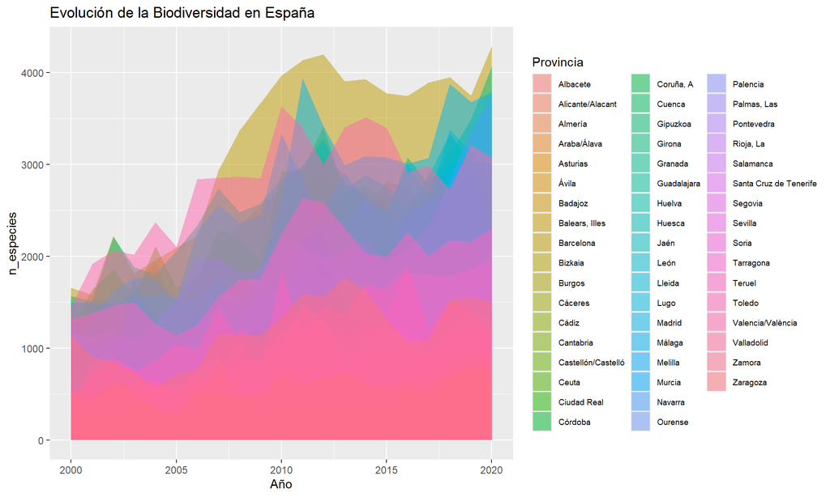

```r
ggplot(gbif_tabla, aes(x = Año, y = n_especies, fill = Provincia)) +
  ggtitle("Evolución de la Biodiversidad en España") +
  geom_area(alpha = 0.5, position = "identity") +
  theme(legend.text = element_text(size = 7))
```

Durante las dos últimas décadas se observa, de forma generalizada, que el número de especies prácticamente se ha duplicado. Este hecho, contrario a lo esperable, se explica probablemente por la mejora de los procesos de identificación y registro de los datos de biodiversidad, haciendo una labor más exhaustiva de recopilación de información.

### Asociación entre la biodiversidad local y el número de pacientes con infección o enfermedad respiratoria

Tratamos de vincular la exposición de la población local a una mayor diversidad con un descenso significativo de las hospitalizaciones por infección. Para ello, contamos con las tablas obtenidas anteriormente:

```r
divers_casos <- df_casos %>%
  select(Año, Lugar_hospitalizacion, Diagnostico_principal, Altas_100mil) %>%
  full_join(gbif_tabla, by = c("Lugar_hospitalizacion" = "Provincia", "Año")) %>%
  select(indice_km2, Diagnostico_principal, Altas_100mil) %>%
  mutate(
    Diagnostico_principal = case_when(
      str_detect(Diagnostico_principal, "respira|RESPIRA|PULMON|Neumonía|Bronqui|Asma|pulmon") ~ "Enfermedad respiratoria",
      str_detect(Diagnostico_principal, "intestinal|INTESTINAL|Gastroenteritis") ~ "Enfermedad del Aparato Digestivo",
      str_detect(Diagnostico_principal, "Equinococosis|PARASIT|parasit|Infec|infec") ~ "Enfermedades Infecciosas y Parasitarias",
      str_detect(Diagnostico_principal, "bacteria|BACTERIA") ~ "Enfermedad Bacteriana",
      str_detect(Diagnostico_principal, "virus|víric|viral") ~ "Enfermedad Vírica",
      str_detect(Diagnostico_principal, "piel|cutáneo|PIEL|Dermatitis|eczema") ~ "Enfermedad de la Piel"
    )
  ) %>%
  filter(!is.na(Altas_100mil), !is.na(Diagnostico_principal))

divers_casos
```

| indice_km2 | Diagnostico_principal | Altas_100mil |
| --- | --- | --- |
| 0.071 | Enfermedad del Aparato Digestivo | 5.267941e+01 |
| 0.118 | Enfermedad del Aparato Digestivo | 9.021380e+01 |
| 0.056 | Enfermedad del Aparato Digestivo | 5.628954e+01 |
| 0.103 | Enfermedad del Aparato Digestivo | 1.018536e+02 |
| 0.056 | Enfermedad del Aparato Digestivo | 4.814836e+01 |
| 0.033 | Enfermedad del Aparato Digestivo | 6.907115e+01 |
| 0.089 | Enfermedad del Aparato Digestivo | 3.667355e+01 |
| 0.027 | Enfermedad del Aparato Digestivo | 7.400930e+01 |
| 0.062 | Enfermedad del Aparato Digestivo | 9.833033e+01 |
| 0.030 | Enfermedad del Aparato Digestivo | 6.521436e+01 |

[output cut: 9990 more lines]

Dibujamos el gráfico con los datos resultantes, con el que podemos estudiar si hay algún sesgo dependiendo del origen de la patología:

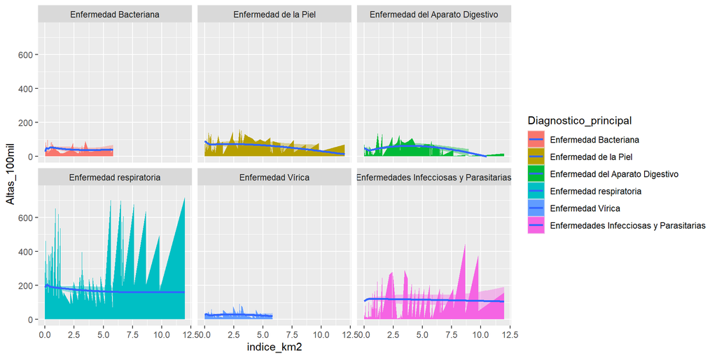

```r
ggplot(divers_casos, aes(x = indice_km2, y = Altas_100mil, fill = Diagnostico_principal)) +
  geom_area(position = "identity") +
  facet_wrap( ~ Diagnostico_principal) +
  xlim(0, 12) +
  ylim(0, 750) +
  geom_smooth()
```

Un análisis preliminar sugiere que, para algunas patologías (enfermedades de la piel o del aparato digestivo), podría existir una relación inversa entre la riqueza específica y la tasa de hospitalización, confirmando nuestra primera hipótesis. No obstante, la relación no es lineal; hay una gran dispersión de valores independientemente de la relación establecida como deseada.

Además, provincias con extensión muy reducida, como Ceuta y Melilla, tienen índices por kilómetro cuadrado excesivamente grandes con respecto al resto de España. Tras su exclusión, es posible observar tendencias más generales.

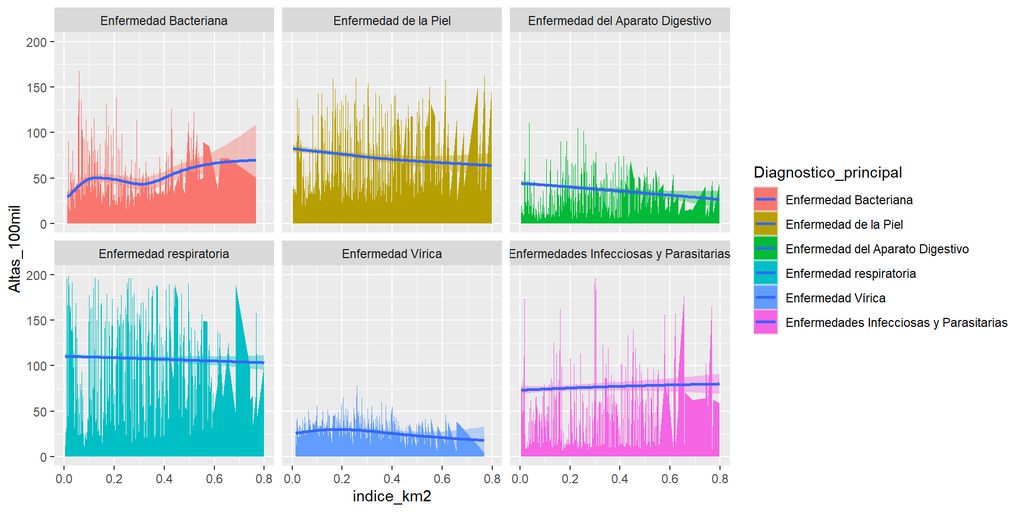

```r
divers_casos <- df_casos %>%
  select(Año, Lugar_hospitalizacion, Diagnostico_principal, Altas_100mil) %>%
  full_join(gbif_tabla, by = c("Lugar_hospitalizacion" = "Provincia", "Año")) %>%
  filter(!(Lugar_hospitalizacion %in% c("Ceuta", "Melilla"))) %>%
  select(indice_km2, Diagnostico_principal, Altas_100mil) %>%
  mutate(
    Diagnostico_principal = case_when(
      str_detect(Diagnostico_principal, "respira|RESPIRA|PULMON|Neumonía|Bronqui|Asma|pulmon") ~ "Enfermedad respiratoria",
      str_detect(Diagnostico_principal, "intestinal|INTESTINAL|Gastroenteritis") ~ "Enfermedad del Aparato Digestivo",
      str_detect(Diagnostico_principal, "Equinococosis|PARASIT|parasit|Infec|infec") ~ "Enfermedades Infecciosas y Parasitarias",
      str_detect(Diagnostico_principal, "bacteria|BACTERIA") ~ "Enfermedad Bacteriana",
      str_detect(Diagnostico_principal, "virus|víric|viral") ~ "Enfermedad Vírica",
      str_detect(Diagnostico_principal, "piel|cutáneo|PIEL|Dermatitis|eczema") ~ "Enfermedad de la Piel"
    )
  ) %>%
  filter(!is.na(Altas_100mil), !is.na(Diagnostico_principal))


ggplot(divers_casos, aes(x = indice_km2, y = Altas_100mil, fill = Diagnostico_principal)) +
  geom_area(position = "identity") +
  facet_wrap(~Diagnostico_principal) +
  xlim(0, 0.8) +
  ylim(0, 200) +
  geom_smooth()
```

Asimismo, el comportamiento observado en el caso de las infecciones bacterianas muestra una tendecia opuesta: la incidencia tiene a aumentar cuanta mayor diversidad haya en el entorno de residencia. Esto cobra sentido si valoramos la capacidad de adaptación de las bacterias, y su frecuente proceso de mutación, que permite su elevada capacidad infecciosa.

### Desarrollo en la infancia de resistencia inmunitaria

Dado que el desarrollo del sistema inmunitario ocurre principalmente durante la infancia, se analizó la evolución de las tasas de hospitalización desagregadas por grupo de edad.

Si nuestra hipótesis fuera correcta, una mayor exposición a antígenos naturales (regiones de alta biodiversidad) llevará, por consiguiente, a un mayor número de casos de infección en edades tempranas, acompañadas de una disminución significativa en adultos.

Una misma provincia tiene, año a año, aproximadamente el mismo índice de diversidad. Por ello, se creará una tabla que relacione cada provincia con su índice medio por kilómetro cuadrado, con el número medio de pacientes por cada 100.000 habitantes.

```r
df_medias <- df_edades %>%
  dplyr::group_by(Año, Lugar_hospitalizacion, Grupo_edad) %>%
  dplyr::summarise(Pacientes = sum(Altas_100mil, na.rm = TRUE)) %>%
  dplyr::group_by(Lugar_hospitalizacion, Grupo_edad) %>%
  dplyr::summarise(Pacientes = mean(Pacientes, na.rm = TRUE)) %>%
  left_join(
    gbif_tabla %>%
      dplyr::group_by(Provincia) %>%
      dplyr::summarise(Índice_medio = mean(indice_km2)),
    by = c("Lugar_hospitalizacion" = "Provincia")
  ) %>%
  arrange(desc(Índice_medio))
df_medias
```

| Lugar_hospitalizacion | Grupo_edad | Pacientes | Índice_medio |
| --- | --- | --- | --- |
| Ceuta | Adultez | 185.60900 | 4.75952381 |
| Ceuta | Infancia | 400.67937 | 4.75952381 |
| Ceuta | Juventud | 70.30045 | 4.75952381 |
| Ceuta | Vejez | 421.63335 | 4.75952381 |
| Melilla | Adultez | 121.78365 | 2.60005000 |
| Melilla | Infancia | 302.19556 | 2.60005000 |
| Melilla | Juventud | 69.88229 | 2.60005000 |
| Melilla | Vejez | 349.31629 | 2.60005000 |
| Gipuzkoa | Adultez | 326.80215 | 0.51714286 |
| Gipuzkoa | Infancia | 155.19528 | 0.51714286 |

[output cut: 198 more lines]

```r
# Ver las provincias con mayores índices de biodiversidad
ordenadas <- df_medias %>%
  dplyr::group_by(Lugar_hospitalizacion) %>%
  dplyr::summarise(Índice_medio = mean(Índice_medio)) %>%
  arrange(desc(Índice_medio))
```

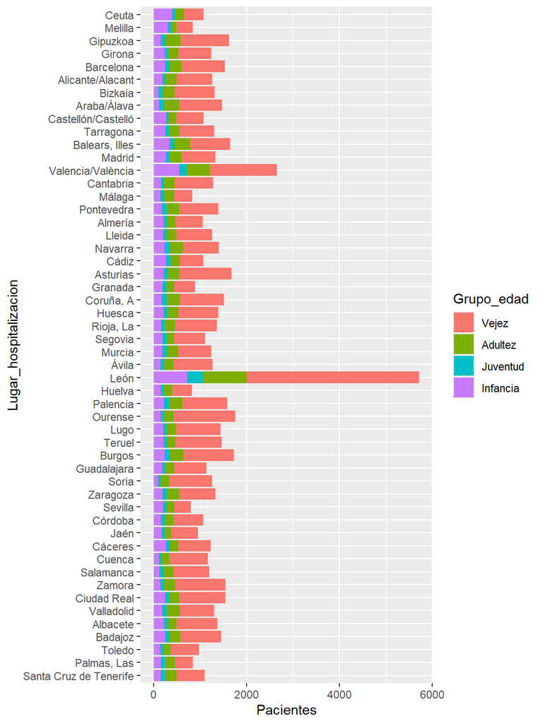

```r
# Queremos mantener el orden según el índice de diversidad
orden <- df_medias %>%
  mutate(Lugar_hospitalizacion = reorder(Lugar_hospitalizacion, Índice_medio)) %>%
  mutate(Grupo_edad = factor(Grupo_edad, levels = c("Vejez", "Adultez", "Juventud", "Infancia")))

ggplot(orden, aes(x = Lugar_hospitalizacion, y = Pacientes, fill = Grupo_edad)) +
  geom_bar(position = "stack", stat = "identity") +
  coord_flip()
```

Quitando la excepción que es León, que puede haber sido causada por problemas en el renombrado (detectar *Castilla y León* como *León*), para una observación más clara de las diferencias:

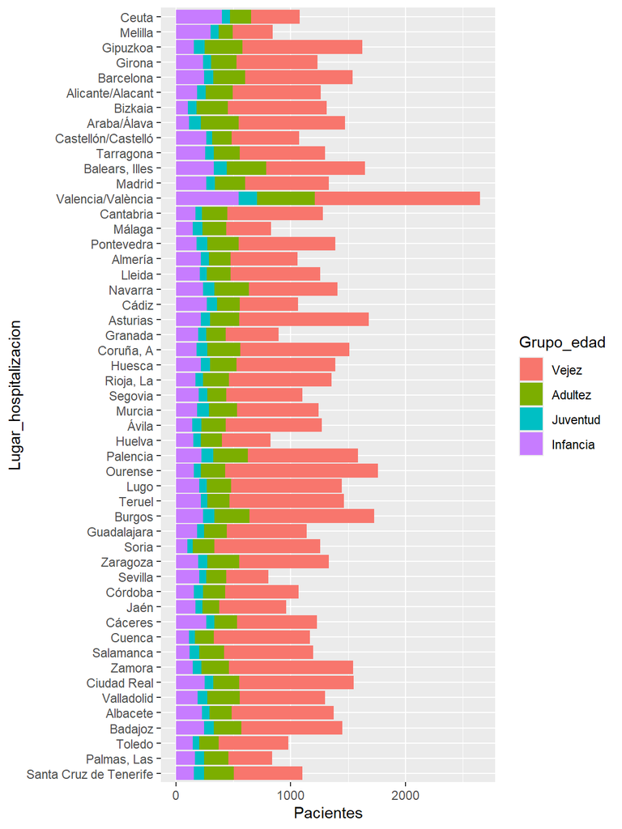

```r
orden <- orden %>%
  filter(Lugar_hospitalizacion != "León")

ggplot(orden, aes(x = Lugar_hospitalizacion, y = Pacientes, fill = Grupo_edad)) +
geom_bar(position = "stack", stat = "identity") +
coord_flip()
```

El análisis consolida la conclusión contraria: no se pueden observar patrones que indiquen un efecto amortiguador entre etapas vitales. Las únicas excepciones notables corresponden a territorios con valores extremadamente altos de diversidad relativa (Ceuta y Melilla).

Por tanto, no podemos concluir que la exposición prolongada a ambientes biodiversos desarrolle mejores prospectos de salud en la población local.

### Biodiversidad y consumo de fármacos

Cada año, podemos estudiar la variación en el consumo de medicamentos por cada comunidad autónoma, que puede establecer una relación entre la diversidad y el estado de salud de la población local común.

[figure not shown]

```r
gbif_meds %>%
  filter(Año == 2014) %>%
  dplyr::rename(num_recetas = `Nº.de.Recetas.CNAC`) %>%
  dplyr::group_by(CCAA) %>%
  dplyr::summarise(
    receta_promedio = mean(num_recetas, na.rm = TRUE),
    indice_km2 = mean(indice_km2, na.rm = TRUE)
  ) %>%
  arrange(indice_km2) %>%
  mutate(CCAA = factor(CCAA, levels = CCAA)) %>%
  ggplot(aes(x = CCAA, y = receta_promedio)) +
  geom_bar(stat = "identity", fill = "deeppink") +
  ylim(0, 200000000) +
  #scale_y_continuous(
    #limits = c(-10, 0),           # De -100% a 0%
    #breaks = seq(-10, 0, 2)      # Saltos cada 10%
  #) +
  labs(
    title = "Variación de medicamentos por Comunidad Autónoma en 2013",
    x = "Comunidad Autónoma",
    y = "Medicamentos Prescritos"
  ) +
  theme_minimal() +
  theme(axis.text.x = element_text(angle = 45, hjust = 1),
        axis.text.y = element_text(size = 6)
  )
```

Es posible ver que no existe una correlación clara entre la biodiversidad y el consumo de medicamentos; incluso podemos considerar por el gráfico que este consumo se hace mayor a medida que aumenta la diversidad.

Ahora bien, este patrón puede verse afectado por múltiples factores que limitan el analisis:

- Ausencia de distinción por categoría terapéutica (antibióticos, antifúngicos, antihistamínicos…), que serían los medicamentos relacionados con nuestro tema central.
- Ausencia de ajuste por población.
- Solo se está estudiando, en este momento, un año. Sin embargo, si empleamos otro periodo un poco alejado:

[figure not shown]

```r
gbif_meds %>%
  filter(Año == 2006) %>%
  dplyr::rename(num_recetas = `Nº.de.Recetas.CNAC`) %>%
  dplyr::group_by(CCAA) %>%
  dplyr::summarise(
    receta_promedio = mean(num_recetas, na.rm = TRUE),
    indice_km2 = mean(indice_km2, na.rm = TRUE)
  ) %>%
  arrange(indice_km2) %>%
  mutate(CCAA = factor(CCAA, levels = CCAA)) %>%
  ggplot(aes(x = CCAA, y = receta_promedio)) +
  geom_bar(stat = "identity", fill = "deeppink") +
  ylim(0, 200000000) +
  #scale_y_continuous(
    #limits = c(-10, 0),           # De -100% a 0%
    #breaks = seq(-10, 0, 2)      # Saltos cada 10%
  #) +
  labs(
    title = "Variación de medicamentos por Comunidad Autónoma en 2013",
    x = "Comunidad Autónoma",
    y = "Medicamentos Prescritos"
  ) +
  theme_minimal() +
  theme(axis.text.x = element_text(angle = 45, hjust = 1),
        axis.text.y = element_text(size = 6)
  )
```

… vemos que tampoco hace una gran diferencia.

Por tanto, el estudio a partir del volumen de fármacos consumido por Comunidad Autónoma no es un método concluyente para probar nuestra última hipótesis.

## Conclusiones

A partir del procesamiento de los datos disponibles, es posible extraer las siguentes conclusiones generales sobre nuestro estudio:

- Los datos aportados por el GBIF no permiten, en su estado actual, evaluar adecuadamente la pérdida de biodiversidad en el territorio español. Sin embargo, el análisis geográfico a través del mapa proporcionado en la **aplicación Shiny** denota un incremento marcado de ocurrencias en las provincias de la costa del Mediterráneo.
- Los resultados sugieren la posible existencia de una relación entre la exposición prolongada a un ambiente de mayor riqueza específica, y el desarrollo de resistencia ante infecciones. Sin embargo, no es una relación directa: el fortalecimiento del sistema inmune depende de múltiples factores que compromenten esta asociación directa.
- El volumen de medicamentos consumidos anualmente no constituye un indicador válido para evaluar el impacto de la biodiversidad sobre la salud, salvo que se restrinja a grupos farmacológicos concretos relacionados con la funciñón inmunitaria. De ahí, podría estudiarse, por ejemplo, si una mayor diversidad fortalece la microbiota y, por tanto, en aquellas comunidades más expuestas se desarrolla una resistencia a los antibióticos (requieren unos de mayor dosis o con periodos de consumo más extendido).

En resumen, solo ha sido posible establecer una asociación preliminar, débil y no concluyente. Este trabajo solo puede servir como base para estudio más complejo, con datos más detalllados y con mayor alcance temporal.

## Referencias

- Strachan DP. Hay fever, hygiene, and household size. BMJ. 1989 Nov 18;299(6710):1259-60. doi: 10.1136/bmj.299.6710.1259. PMID: 2513902; PMCID: PMC1838109. https://pmc.ncbi.nlm.nih.gov/articles/PMC1838109/
- von Hertzen L, Hanski I, Haahtela T. Natural immunity. Biodiversity loss and inflammatory diseases are two global megatrends that might be related. EMBO Rep. 2011 Oct 28;12(11):1089-93. doi: 10.1038/embor.2011.195. PMID: 21979814; PMCID: PMC3207110. https://pmc.ncbi.nlm.nih.gov/articles/PMC3207110/
- Haahtela T, Alenius H, Lehtimäki J, Sinkkonen A, Fyhrquist N, Hyöty H, Ruokolainen L, Mäkelä MJ. Immunological resilience and biodiversity for prevention of allergic diseases and asthma. Allergy. 2021 Dec;76(12):3613-3626. doi: 10.1111/all.14895. Epub 2021 May 24. PMID: 33959980. https://pubmed.ncbi.nlm.nih.gov/33959980/
- Base de datos morbilidad: https://www.ine.es/dyngs/INEbase/operacion.htm?c=Estadistica_C&cid=1254736176778&menu=resultados&idp=1254735573175#_tabs-1254736194704
- Comité Científico de la Agencia Española de Seguridad Alimentaria y Nutrición (AESAN), Díaz Perales, A., Aguilera García, C.M., Bretón Lesmes, I., Gil Izquierdo, A., Nieto Martínez, G., Rivas Velasco, A.M., Sánchez Mata, M-C. (2023). Informe del comité científico de la agencia española de seguridad alimentaria y nutrición (AESAN) sobre los efectos del cambio climático en la alergia alimentaria. Revista del Comité Científico de la AESAN, 38, 25-44.
- Instituto Nacional de Estadística. Estadística sobre actividades de Investigación y Desarrollo. https://www.ine.es/dyngs/INEbase/operacion.htm?c=Estadistica_C&cid=1254736176778&menu=resultados&idp=1254735573175#_tabs-1254736194704
- Ministerio de Sanidad, Gobierno de España. Consumo farmacéutico del SNS: CCAA e INGESA. Portal Estadístico del SNS. https://pestadistico.inteligenciadegestion.sanidad.gob.es/publicoSNS/I/consumo-farmaceutico-del-sns/consumo-farmaceutico-ccaa-e-ingesa